# Get started with single-cell DNA copy number analyses

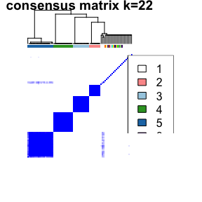

```
#> consensus  24
#> clustered
```

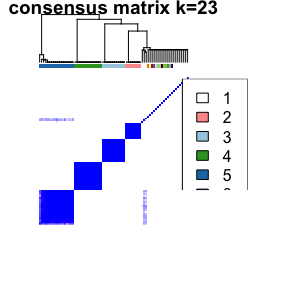

```
#> consensus  25
#> clustered
```

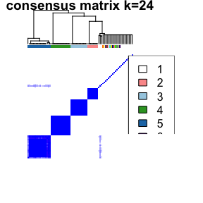

```
#> consensus  26
#> clustered
```

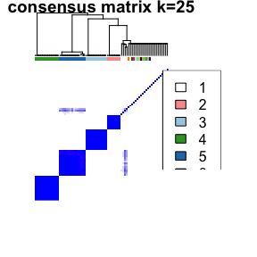

```
#> consensus  27
#> clustered
```

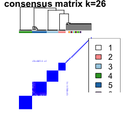

```
#> consensus  28
#> clustered
```

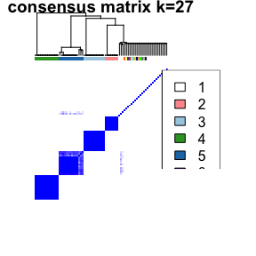

```
#> consensus  29
#> clustered
```

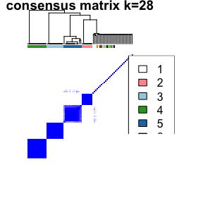

```
#> consensus  30
#> clustered
```

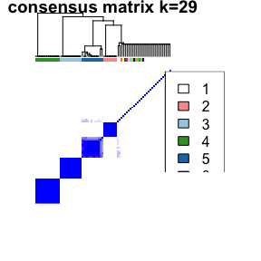

```
#> consensus  31
#> clustered
```

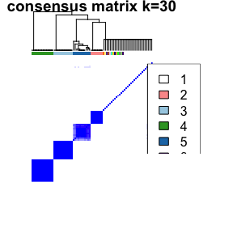

```
#> consensus  32
#> clustered
```

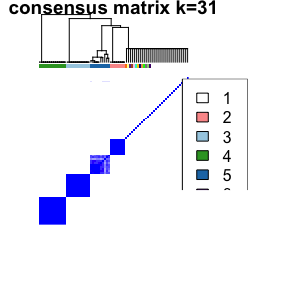

```
#> consensus  33
#> clustered
```

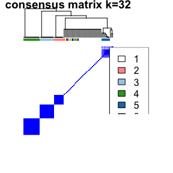

```
#> consensus  34
#> clustered
```

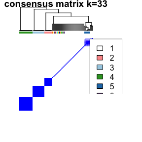

```
#> consensus  35
#> clustered
```

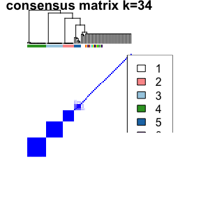

```
#> consensus  36
#> clustered
```

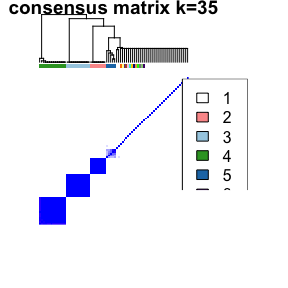

```
#> consensus  37
#> clustered
```

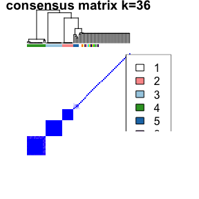

```
#> consensus  38
#> clustered
```

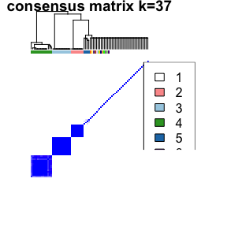

```
#> consensus  39
#> clustered
```

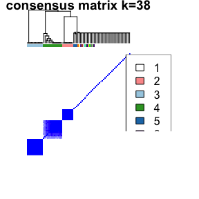

```
#> consensus  40
#> clustered
```

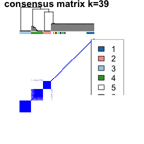

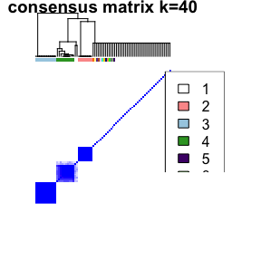

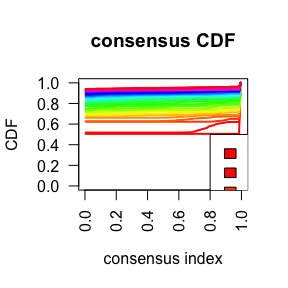

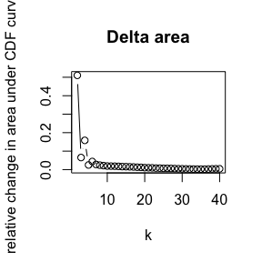

```
#> kCC = 2...
#> kCC = 3...
#> kCC = 4...
#> kCC = 5...
#> kCC = 6...
#> kCC = 7...
#> kCC = 8...
#> kCC = 9...
#> kCC = 10...
#> kCC = 11...
#> kCC = 12...
#> kCC = 13...
#> kCC = 14...
#> kCC = 15...
#> kCC = 16...
#> Using recommended kCC = 11 by kSpectral
```

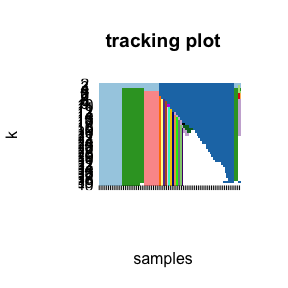

## Analysis considerations

- Filtering noisy cells is an iterative process. QC metrics such as ReadsAligned, MAPD, sequence quality, and other metrics are particularly useful to exclude technical artifacts. Clustering can help spot groups of problematic cells.
- If the data does not contain a suitable root.cell, consider building an in-silico diploid cell, and clone to use in the analysis
- We prefer the use of Consensus Clustering with Spectral anaysis over heirarchical clustering. The current set up is to select the maximum number of stable clones. As a result, some larger clones may get broken up into two or three subclones. Future versions will be focused to address this.
- By default, consensus clustering is interated 200 times. This number is particularly low, and should be increased. The specific number of times will depend on the complexity of the data, and the confidence desired to separate specific groups of cells. Our current analyses are set at `iter = 1000` and left to run over a weekend`
- Cluster Heterogeneity can be split by a variable. E.g. sample, region information, histology, etc.

## Session Informatioin

```r
date()
```

```
#> [1] "Thu Sep  8 09:28:09 2022"
```